# Effective Data Visualisation with R **Qualitative Data**

Paul Murrell The University of Auckland

# Review

- A data visualisation consists of data symbols, guides, and labels.
- A data visualisation can help to answer questions.
  - An effective data visualisation will pose questions that the visual system is good at answering.
- We need to choose a mapping from data values to data symbols.
  - **An effective data visualisation will have good mappings from data to data symbols.**

# Visual Features

- The combination of geom and aesthetic that we choose maps data values to a **visual feature**.

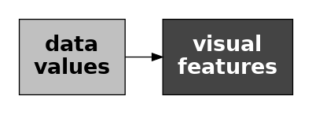

- Visual features are the properties of data symbols that our visual system identifies very rapidly, in parallel, and without conscious effort.
- Our task is to identify a good mapping from data values to visual features.

# Effective Visual Features

- One idea is to select geoms and aesthetics so that data values are mapped to visual features that have the same **type** as the data.
- For visualising **qualitative** data, we need to identify which visual features are **qualitative** visual features.

# Qualitative Data

- Qualitative features
- Ordinal features
- Qualitative scales
- Colour
- Feature mismatch
- Gestalt Principles

Qualitative Features

# Qualitative Features

- **Colour** and **shape** are examples of visual features that can represent qualitative values.
- **Position** is also very effective for qualitative data.

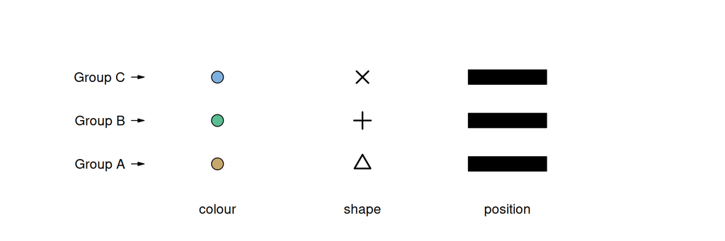

# Qualitative Features

- By contrast, **length**, **area**, and **angle** are *not* appropriate for representing qualitative values.

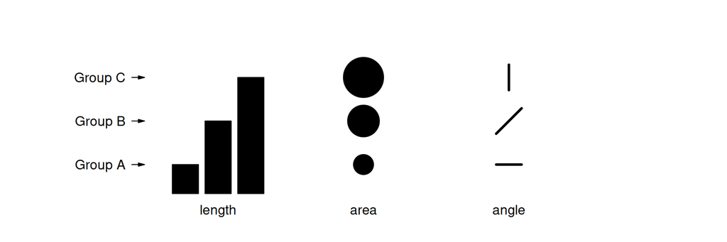

# Qualitative Data

- The `RWCperGame` data frame contains measures of performance at the Rugby World Cup of 2023 for different countries, plus the `hemisphere` that each country is from.
- `hemisphere` is an example of **qualitative** data.

  ```
  # A tibble: 6 × 11
    country   hemisphere yellowcards redcards cleanbreaks
    <chr>     <fct>            <dbl>    <dbl>       <dbl>
  1 Namibia   South             1        0.5         2.5
  2 Romania   North             1.25     0           2.75
  3 Chile     South             1.25     0           3.75
  4 Samoa     South             1.25     0.25        3.75
  5 Australia South             0.5      0           5.25
  6 Georgia   North             0.5      0           5.25
  # ℹ 6 more variables: tackles <dbl>, points <dbl>,
  #   conversions <dbl>, offloads <dbl>, tries <dbl>,
  #   runs <dbl>
  ```

# Qualitative Data

- We map **qualitative** data to a visual feature in order to be able to identify values that belong to different groups or categories.
- If we map `hemisphere` to a **qualitative** visual feature, we can answer questions like:
  - Do teams from the Northern `hemisphere` make more clean breaks than teams from the South (on average)?
  - The crucial visual task is to distinguish data for Northern teams from data for Southern teams.

> We can visualise **qualitative** data using the **shape** of **points**.
- Do teams from the Northern `hemisphere` make more clean breaks than teams from the South (on average)?

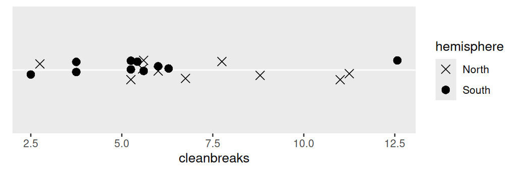

# Qualitative Features in {ggplot2}

- `geom_point()` and the `shape` aesthetic map data values to **shape**.

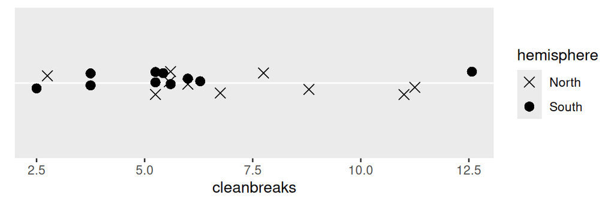

```r
ggplot(RWCperGame) +
    geom_point(aes(x=cleanbreaks, y="", shape=hemisphere),
               position=position_jitter(width=0, height=.1, seed=123))
```

# Qualitative Features in {ggplot2}

- The `x` and `y` aesthetics map qualitative data values to **position** for `geom_point()` and `geom_col()`.

```r
ggplot(RWCperGame) +
    geom_point(aes(x=cleanbreaks, y=hemisphere),
               position=position_jitter(width=0, height=.1, seed=123))
```

[output not shown]

# Qualitative Features in {ggplot2}

- The `colour` aesthetic maps data values to **colour** for `geom_point()`, `geom_col()`, and `geom_line()`.

```r
ggplot(RWCperGame) +
    geom_point(aes(x=cleanbreaks, y="", colour=hemisphere),
               position=position_jitter(width=0, height=.1, seed=123))
```

[output not shown]

# Qualitative Features in {ggplot2}

- When the geom has an interior, the `colour` aesthetic maps data values to the **border colour** and the `fill` aesthetic maps data values to the **fill colour**.

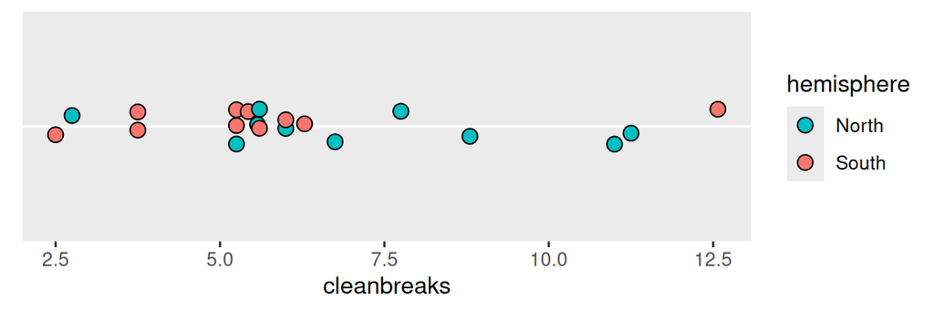

```r
ggplot(RWCperGame) +
    geom_point(aes(x=cleanbreaks, y="", fill=hemisphere), pch=21,
               position=position_jitter(width=0, height=.1, seed=123))
```

Ordinal Features

# Ordinal Data

- The `crimeLevelTotal` data frame contains the `total` number of offences broken down by `level` of crime.
- Are less severe crimes more common than more severe crimes?

```r
crimeLevelTotal
```

```
# A tibble: 5 × 3
  level       total   prop
  <ord>       <int>  <dbl>
1 Low         24242 0.283
2 Low-Medium  21513 0.251
3 Medium      13823 0.161
4 Medium-High 18315 0.214
5 High         7793 0.0909
```

# Ordinal Features

- We perceive darker colours as “greater than” lighter colours.

Qualitative Scales

# Qualitative Scales

- The mapping from data values to a visual feature also depends on the **scale** of the mapping.
- How are data values transformed to values on the visual feature?

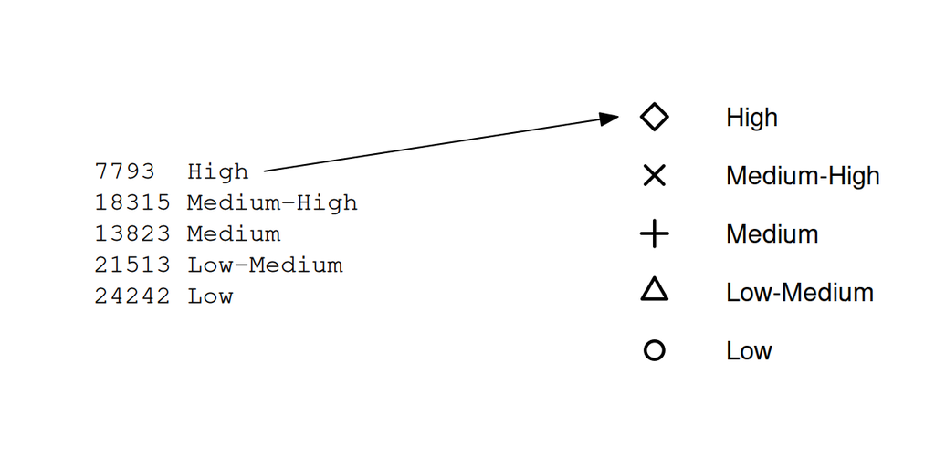

# The Principle of Unambiguity

- The scale should be chosen so that differences in the data are visible in the data visualisation.

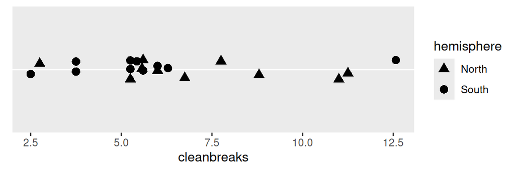

# Qualitative Scales in {ggplot2}

- We can control the set of **shapes** that data values are mapped to using `scale_shape_manual()`.

[figure not shown]

# Qualitative Scales in {ggplot2}

- We can control how qualitative values are mapped to **position** with `scale_y_discrete()`.

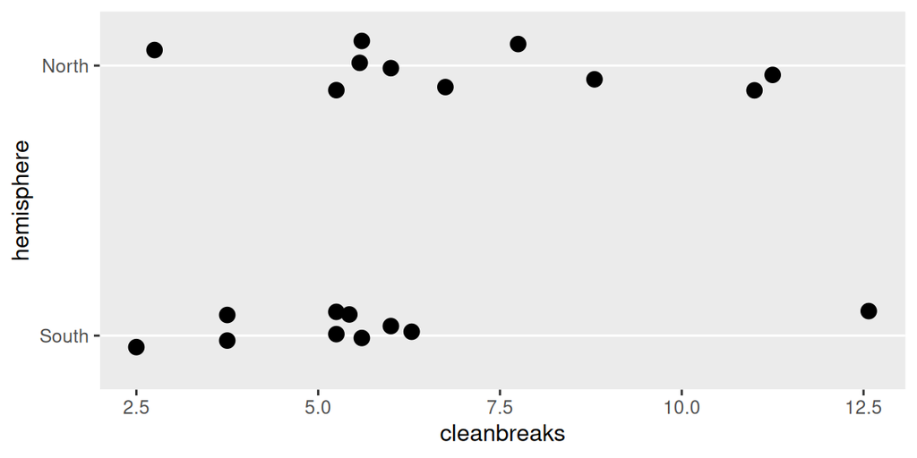

```r
ggplot(RWCperGame) +
    geom_point(aes(x=cleanbreaks, y=hemisphere),
               position=position_jitter(width=0, height=.1, seed=123)) +
    scale_y_discrete(expand=expansion(c(.2, .2)))
```

Colour

# Qualitative Scales

- The mapping from data values to a visual feature also depends on the **scale** of the mapping.
- How are data values transformed to values on the visual feature?

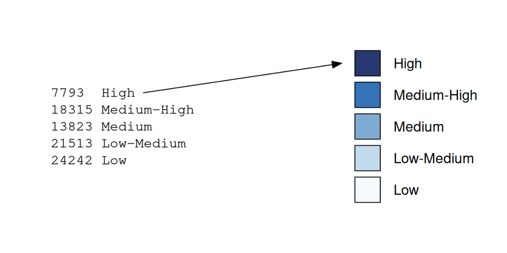

# Qualitative Scales

- `scale_colour_manual()` and `scale_fill_manual()` allow us to select the colours that data values map to.

# Qualitative Scales

- However, there are a LOT of colours to choose from!

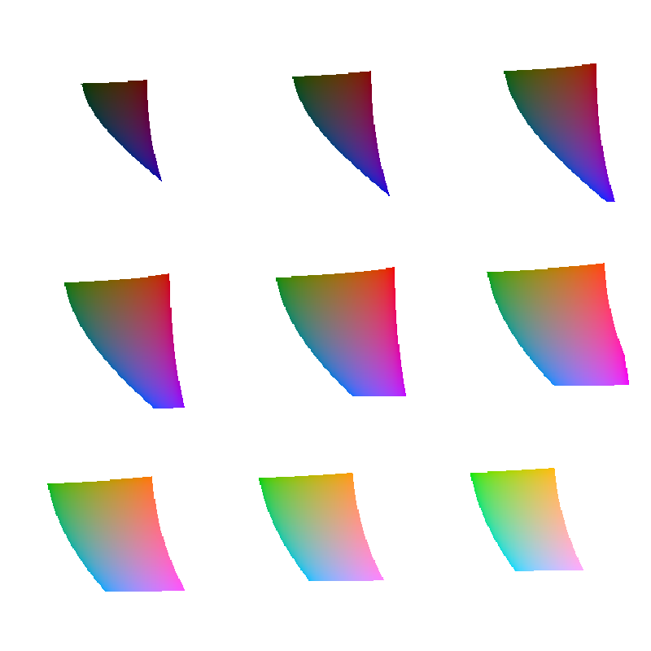

# Colour

- We have been talking about **colour** as if it is a single visual feature, but it can be split into three distinct features: **hue**, **chroma** (colourfulness), and **luminance** (light/dark).

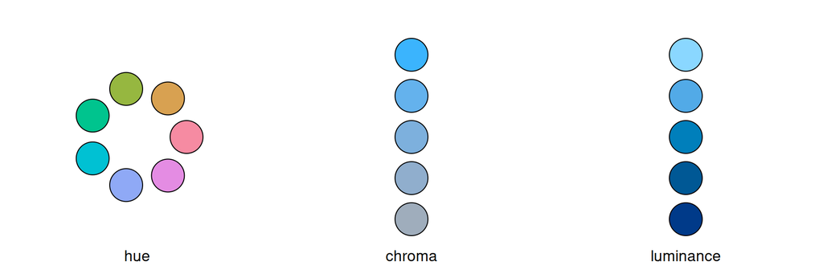

# Colour Palettes

- Varying **hue** creates a **qualitative** colour palette.

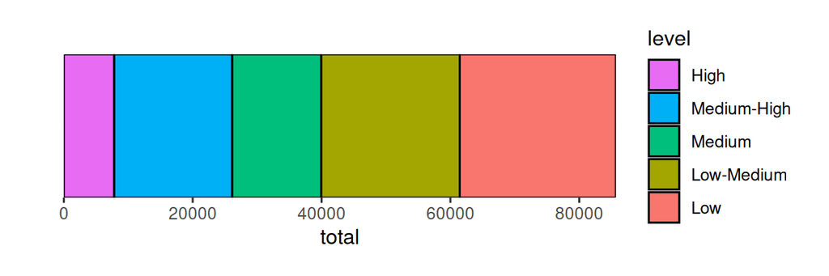

  ```r
  ggplot(crimeLevelTotal) +
      geom_col(aes(x=total, y="", fill=level), colour="black") +
      scale_fill_hue()
  ```

# Colour palettes

- Varying **chroma** or **luminance** (or both) creates an **ordinal** (or **sequential**) colour palette.

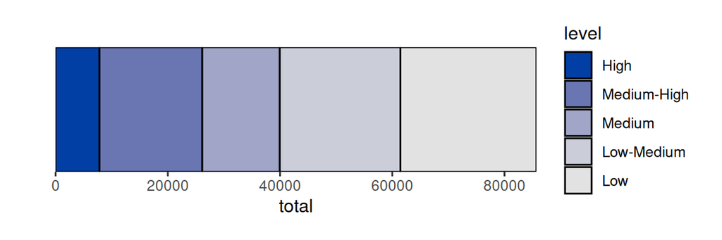

  ```r
  ggplot(crimeLevelTotal) +
      geom_col(aes(x=total, y="", fill=level), colour="black") +
      colorspace::scale_fill_discrete_sequential()
  ```

# Colour palettes

- A **diverging** colour palette combines two sequential palettes with a neutral centre.

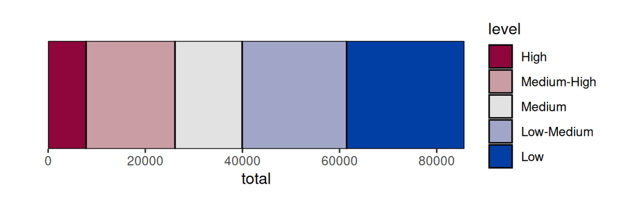

  ```r
  ggplot(crimeLevelTotal) +
      geom_col(aes(x=total, y="", fill=level), colour="black") +
      colorspace::scale_fill_discrete_diverging()
  ```

- Selecting a colour palette is a complex task, with competing constraints.
- On one hand there is a desire for visual balance in order to avoid emphasising one category over another.

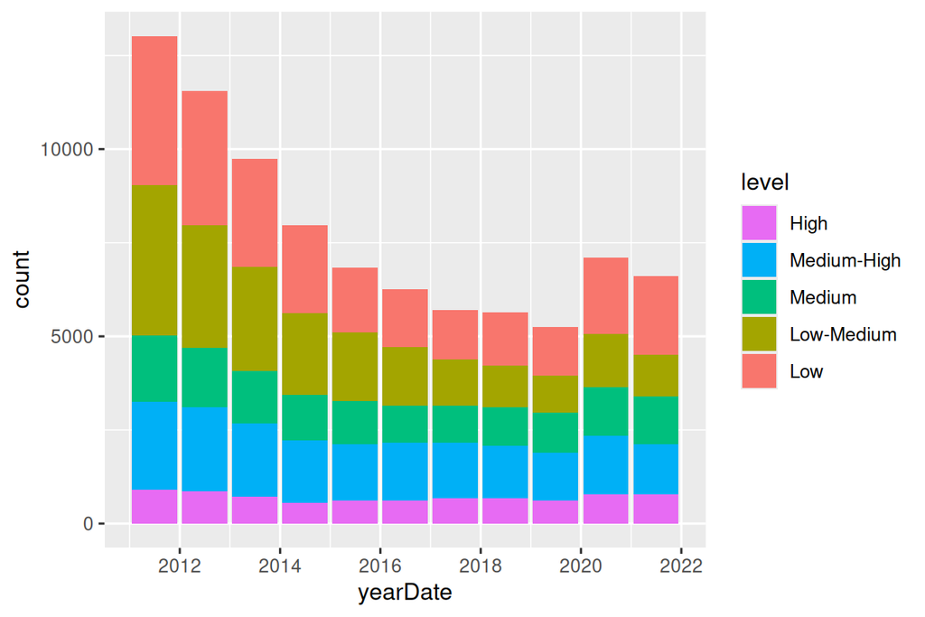

- But that does not translate well to greyscale for printing.

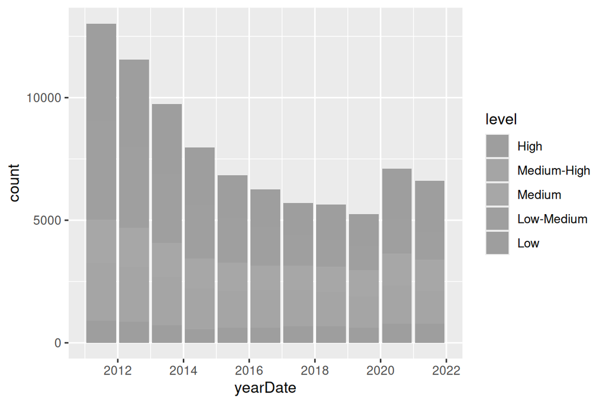

- There is also a need to account for colour-vision deficiency.

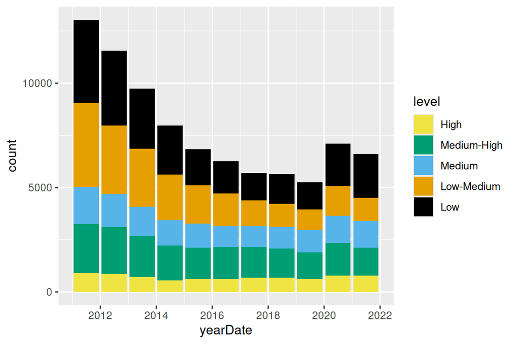

- This shows what the previous colour palette might look like to a colour blind viewer.

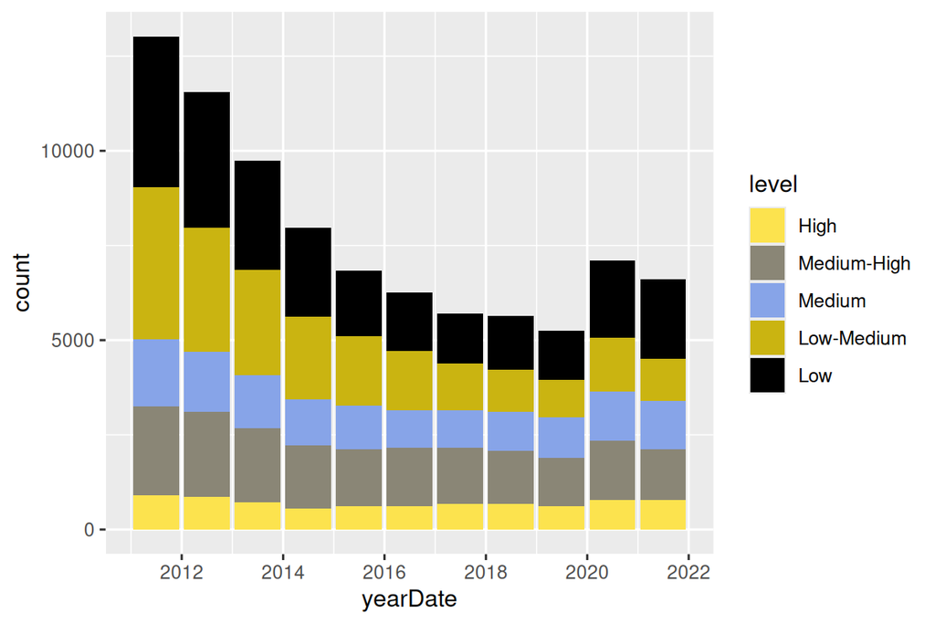

- There are also situations where a deliberate emphasis is desired in order to highlight one particular category.

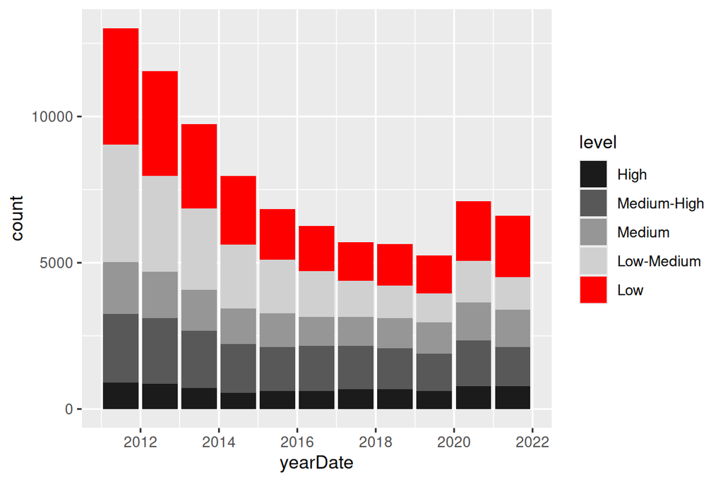

# Colour Palettes in {ggplot2}

- There are a number of [predefined colour scales](https://ggplot2.tidyverse.org/reference/#scales) in {ggplot2}.

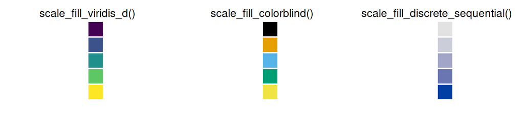

- The R Journal article [Coloring in R’s Blind Spot](https://journal.r-project.org/articles/RJ-2023-071/) also offers some advice.

Feature Mismatch

# Feature Mismatch

- If the visual feature has a “higher” type than the data, we risk *adding* superfluous or incorrect information.

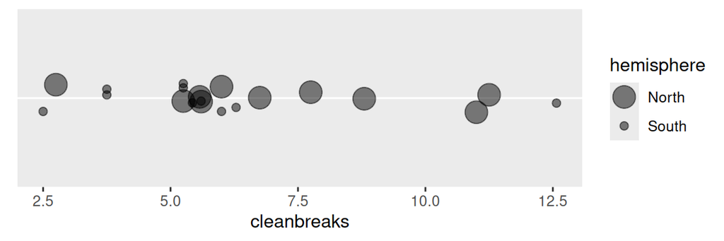

Gestalt Principles

# Gestalt Principles

- An effective qualitative mapping maps **different** data values to **visually different** data symbols.

# Gestalt Principles

- An effective qualitative mapping maps **the same** data values to **visually similar** data symbols.

# Gestalt Principles

- An effective qualitative mapping maps **groups** of data values to **visual groups** of data symbols.

# Gestalt Principles

- The Gestalt psychologists identified several principles of visual grouping.

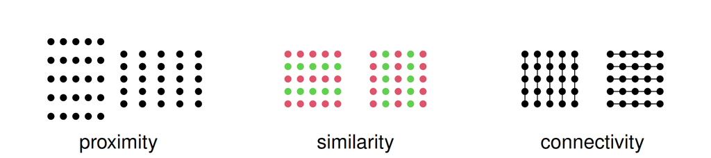

- These are examples of visual processing that happen very rapidly and early in our visual system.

# Gestalt Principles: Similarity

- Mapping the same qualitative data to the same **colour** or **shape** produces visual groups through **similarity**.

# Gestalt Principles: Proximity

- Mapping the same qualitative data to the same **position** produces visual groups through **proximity**.